# When do the big waves come? A year on two neighbouring wave buoys

- Show All Code
- Hide All Code
- View Source

Assignment 4 ETC5512

Author

Hanwen Liu

**Data and Documenting**

### Q1 — The question

This blog post answers, from a full year of half-hourly wave-buoy records:

> **How did wave conditions and sea temperature change across 2025 off the Gold Coast, when did the biggest-wave events arrive, and how does wave height relate to wave period (swell versus local wind-sea) — and does a second buoy 27 km south tell the same story?**

I chose this question because it is tightly scoped — one year, two open datasets — yet rich enough to exercise a wide range of the unit’s skills: datetime parsing, sentinel-value cleaning, aggregating a 17,520-row half-hourly series, joining two datasets on a common time grid, and time-series, seasonal, spatial and correlation analysis. Adding the second buoy is deliberate: rather than just describing one record, it lets me *test* whether the patterns are real signals in the ocean or merely one instrument’s quirks.

### Q2 — The data

I use **two** datasets from the **Queensland Government Open Data Portal**, both the “Wave data – 2025” resource of a *Coastal Data System – Waves* dataset, both **observational sensor data** from a **Datawell Directional Waverider** buoy recording a 26.6-minute sample every **30 minutes**.

|  | **Dataset 1 — Gold Coast** (primary) | **Dataset 2 — Tweed Heads** (comparison) |
| --- | --- | --- |
| Source / custodian | DETSI + City of Gold Coast | DETSI + Tweed River Sand Bypassing |
| Location | 27.965° S, 153.441° E, 17 m depth | 28.177° S, 153.576° E, 22 m depth |
| Rows (2025) | 17,520 | 17,520 (after clipping to 2025) |
| Licence | CC BY 4.0 | CC BY 4.0 |
| Portal | [link](https://www.data.qld.gov.au/dataset/coastal-data-system-waves-gold-coast) | [link](https://www.data.qld.gov.au/dataset/coastal-data-system-waves-tweed-heads) |

**Type.** Neither is a survey or an experiment; each is effectively a **census** of every valid half-hourly record the buoy made in 2025 — a complete, regular time grid.

**Why this suits the question.** Each file carries exactly the variables I need — significant and maximum wave height (`Hs`, `Hmax`), two wave periods (`Tz`, `Tp`), peak wave direction, and sea surface temperature (`SST`). One buoy answers the “when” questions; the **second, 27 km south, is what lets me check whether the answers are real**. Both are ~1 MB and openly licensed, so the work is fully reproducible.

**Limitations.**

- **Missing data is coded, not blank.** Failed readings are the sentinel `-99.9`; untreated it would poison every average. Gold Coast is ~4.5% missing for wave parameters — but **not evenly**: **March alone is ~25.1% missing** (an outage). Tweed Heads is far more complete (~0.1%), which turns out to matter.
- **Two buoys, one year.** Findings describe these sites in 2025, not a long-term climatology.
- **Point in space.** A buoy measures open-water sea state, not the breaking surf at any particular beach.

**Ethics & privacy.** Both datasets measure the physical ocean only — **no people, vessels or identifiable subjects** — so privacy/re-identification risk is negligible. The obligations are *attribution* (CC BY 4.0) and *responsible interpretation*: this is a curiosity project, **not** a marine-safety product.

### Q3 — Downloading and processing the data

**Download (`R/01_download.R`).** The script downloads each buoy’s CSV from its portal URL and **falls back to the committed copy in `data/raw/`** if the portal is unreachable, so the pipeline reproduces online *or* offline. Raw files are never edited by hand.

```r
ok <- tryCatch({ download.file(s$url, s$dest, mode = "wb"); TRUE },
               error = function(e) FALSE, warning = function(w) FALSE)
if (!ok && !file.exists(s$dest)) stop("Download failed and no committed copy.")
header <- strsplit(readLines(s$dest, n = 1), ",")[[1]]
stopifnot(identical(header, expected_cols))
```

**Process (`R/02_clean_process.R`).** The core steps — applied to both buoys:

```r
read_buoy <- function(path, site) {
  read_csv(path, col_types = cols(`Date/Time (AEST)` = col_character(),
                                  .default = col_double())) %>%
    mutate(site = site, .before = 1)
}
waves <- bind_rows(read_buoy(gc_path, "Gold Coast"),
                   read_buoy(tw_path, "Tweed Heads")) %>%
  mutate(datetime = ymd_hms(`Date/Time (AEST)`, truncated = 1, tz = "Australia/Brisbane")) %>%
  mutate(across(c(hs, hmax, tz, tp, dir, sst), \(x) if_else(x == -99.9, NA, x))) %>%
  filter(year(datetime) == 2025)
```

The pipeline then runs **per-site assertions** (each site: 17,520 rows, every timestamp parsed, no duplicates, a regular 30-minute grid) and writes two **processed** datasets: `waves_2025_clean.csv` (tidy half-hourly, both sites, sentinel → `NA`) and `waves_2025_monthly.csv` (site × month summary). Raw and processed data are both saved under `data/`.

### Q4 — Data documentation for markers

Full documentation lives alongside the data:

- **`docs/metadata.md`** — provenance, custodians, licences, coverage, instruments, ethics (both buoys).
- **`docs/data_dictionary.csv`** — every variable with units, valid 2025 range and missing code.
- **`README.md`** — folder map and one-command reproduction steps.

A **sample of a raw file** (note the `-99.9` sentinel and the half-hourly step):

```r
read_csv("data/raw/gold-coast-mk4-2025-waveverifieddata.csv", n_max = 3,
         col_types = cols(.default = col_character())) |>
  knitr::kable(caption = "First 3 rows of the Gold Coast raw CSV.")
```

First 3 rows of the Gold Coast raw CSV.

| Date/Time (AEST) | Hs (m) | Hmax (m) | Tz (s) | Tp (s) | Peak Direction (degrees) | SST (degrees C) |
| --- | --- | --- | --- | --- | --- | --- |
| 2025-01-01T00:00 | 0.704 | 1.321 | 4.121 | 7.143 | 101.48 | 25.560 |
| 2025-01-01T00:30 | 0.714 | 1.272 | 4.305 | 5.714 | 105.09 | 25.560 |
| 2025-01-01T01:00 | 0.728 | 1.280 | 4.684 | 7.143 | 105.00 | 25.520 |

**Missingness by month and site** — the one big gap is Gold Coast in March; Tweed Heads is near-complete all year (this is what makes it a useful cross-check):

```r
monthly |>
  ggplot(aes(month, pct_missing_hs, fill = site)) +
  geom_col(position = position_dodge(width = 0.8), width = 0.7) +
  scale_fill_manual(values = site_cols, name = NULL) +
  labs(x = NULL, y = "% missing Hs",
       title = "Where are the gaps?  Missing wave readings by month, 2025") +
  scale_y_continuous(expand = expansion(mult = c(0, 0.12))) +
  theme(legend.position = "top")
```

Table 1

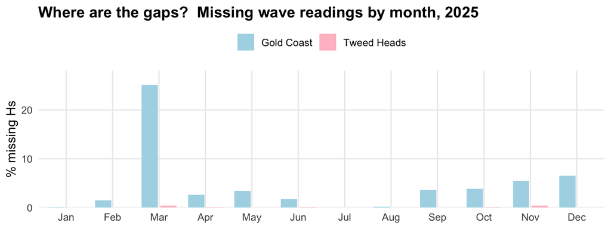

Percentage of half-hours with no valid Hs reading, by month and buoy. Gold Coast’s ~25% March outage is the one large gap; Tweed Heads is near-complete all year.

**Blog post**

### Reading the ocean’s diary, one buoy at a time

Every thirty minutes, a yellow buoy bobbing off the Gold Coast writes a single line in a diary: how big the waves are, how far apart, which way they’re marching, and how warm the sea is. Do that for a year and you get **17,520 lines** — a complete record of one patch of ocean through 2025. I wanted to read that diary and answer three things I’ve always wondered about as someone who watches the coast: *when is the sea roughest, when do the genuinely big swells turn up, and what does the data say about “swell” versus messy local “wind-sea”?* Then I do the honest thing and ask a fourth: **is any of it real, or just this one buoy?**

#### Two rhythms that don’t keep time together

The first thing the year reveals is that the ocean keeps **two different clocks**.

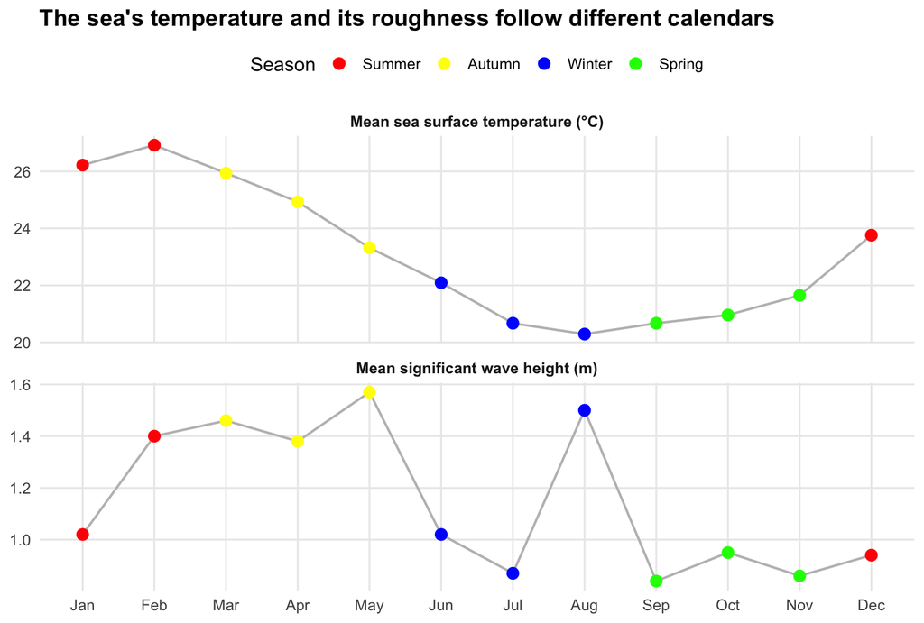

Figure 1: Two seasonal rhythms off the Gold Coast in 2025. Sea temperature (top) follows a smooth solar cycle that lags the calendar — warmest in late summer, coldest in late winter. Wave height (bottom) does not: it peaks in autumn and has a sharp winter spike, and is calmest in spring. Points are coloured by Southern-Hemisphere season.

```r
monthly_gc %>%
  transmute(month, season,
            `Mean significant wave height (m)` = mean_hs,
            `Mean sea surface temperature (°C)` = mean_sst) %>%
  pivot_longer(-c(month, season), names_to = "metric", values_to = "value") %>%
  ggplot(aes(month, value, group = 1)) +
  geom_line(colour = "grey", linewidth = 0.7) +
  geom_point(aes(colour = season), size = 3) +
  facet_wrap(~ metric, ncol = 1, scales = "free_y") +
  scale_colour_manual(values = season_cols, name = "Season") +
  labs(x = NULL, y = NULL,
       title = "The sea's temperature and its roughness follow different calendars") +
  theme(legend.position = "top")
```

**Sea temperature** behaves exactly as you’d hope a thermometer would: a smooth wave from a warm **Feb (26.9°C)** down to a cold **Aug (20.3°C)** — a swing of about **6.6°C** across the year. Notice it *lags the calendar*: the warmest month is late summer, not the summer solstice, and the coldest is late winter. That delay is the ocean’s huge thermal inertia — water is slow to heat and slow to cool.

**Wave height keeps a stubbornly different beat.** The roughest month is **May (mean Hs 1.57 m)** and the calmest is **Sep (0.84 m)**. Seas build through autumn, throw a spike in late winter, then go quiet in spring — *not* tracking temperature at all. Waves are made by **wind and distant storms**, which have their own seasonal calendar, so the two curves drift in and out of step. That mismatch is the whole point of the chart, and it sets up a trap I’ll spring at the end.

#### When do the big waves actually come?

A monthly average hides the drama. If I instead take the **biggest wave each day** and mark every half-hour where significant height topped a stormy **3 m** (only **93** half-hours all year, 0.56% of the time), the big events don’t dribble out evenly — they **clump**.

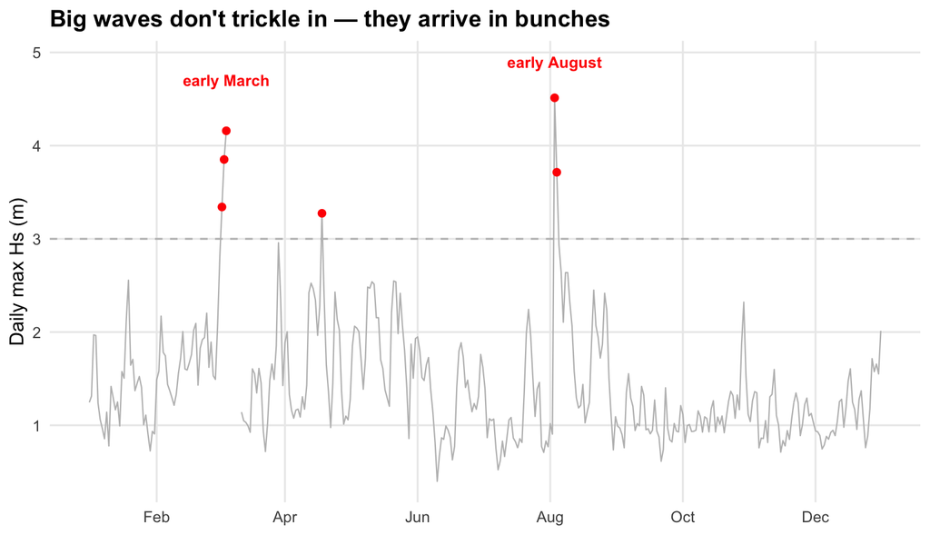

Figure 2: Daily maximum significant wave height at the Gold Coast through 2025. Most days sit below 2 m; the genuinely big seas (red, Hs ≥ 3 m) cluster into a few multi-day events, overwhelmingly in autumn (early March) and a sharp burst in late winter (early August).

```r
gc %>%
  group_by(date) %>%
  summarise(max_hs = max(hs, na.rm = TRUE), .groups = "drop") %>%
  mutate(max_hs = ifelse(is.finite(max_hs), max_hs, NA_real_)) %>%
  ggplot(aes(date, max_hs)) +
  geom_hline(yintercept = 3, linetype = "dashed", colour = "grey") +
  geom_line(colour = "grey", linewidth = 0.4) +
  geom_point(data = ~ filter(.x, max_hs >= 3), colour = "red", size = 1.8) +
  annotate("text", x = as.Date("2025-03-05"), y = 4.7, label = "early March",
           colour = "red", size = 3.4, fontface = "bold") +
  annotate("text", x = as.Date("2025-08-03"), y = 4.9, label = "early August",
           colour = "red", size = 3.4, fontface = "bold") +
  scale_x_date(date_breaks = "2 months", date_labels = "%b") +
  labs(x = NULL, y = "Daily max Hs (m)",
       title = "Big waves don't trickle in — they arrive in bunches")
```

Two events dominate the year, and the lovely twist is that they sit in **opposite seasons at opposite sea temperatures**:

- **Early March (warm, autumn).** This event produced the year’s **largest single wave**, an `Hmax` of **7.47 m** on **05 March**, while the sea was still a balmy **26.4°C** — the signature of a warm east-coast low / ex-tropical system. Gold Coast’s ~25% March outage means we’re probably *under*-counting this one (more on that below).
- **Early August (cold, winter).** This produced the year’s **highest significant height**, **Hs 4.51 m** on **03 August**, with the sea down at **19.9°C** — a classic cold-season, long-period swell.

So “big-wave season” in 2025 wasn’t a single season at all: the two heavyweights came from completely different weather, half a year and ~6.5°C apart.

#### Swell or slop? What the wave period tells us

Surfers care less about raw height than about **period** — long, orderly *swell* from distant storms versus short, choppy *wind-sea* from local weather. Plotting every half-hour of height against peak period separates the two:

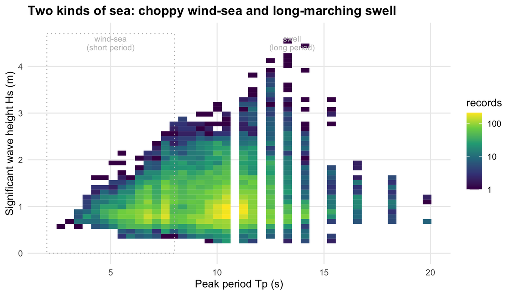

Figure 3: Every valid half-hour of Gold Coast significant wave height vs peak period (colour = number of records, log scale). The cloud has two homes: short-period local wind-sea on the left, and a long-period swell band around 9–14 s on the right where the biggest seas live. Beyond ~14 s sit long but low waves — tired swell that has travelled a long way.

```r
gc %>%
  filter(!is.na(hs), !is.na(tp)) %>%
  ggplot(aes(tp, hs)) +
  geom_bin2d(bins = 45) +
  scale_fill_viridis_c(trans = "log10", name = "records", labels = label_number()) +
  annotate("rect", xmin = 2, xmax = 8, ymin = 0, ymax = 4.7,
           fill = NA, colour = "grey", linetype = "dotted") +
  annotate("text", x = 5, y = 4.5, label = "wind-sea\n(short period)",
           size = 3.2, colour = "grey", lineheight = 0.9) +
  annotate("text", x = 13.5, y = 4.5, label = "swell\n(long period)",
           size = 3.2, colour = "grey", lineheight = 0.9) +
  labs(x = "Peak period Tp (s)", y = "Significant wave height Hs (m)",
       title = "Two kinds of sea: choppy wind-sea and long-marching swell")
```

The relationship is real but **weak** (correlation 0.16): longer-period seas tend to be bigger, yet plenty of long-period records are small. Binning confirms it — mean height climbs from ~0.9 m at the shortest periods to ~1.35 m in the **12–14 s** swell band, then *falls back* for the very longest periods (> 14 s). Those longest waves are **decayed swell from far-off Southern Ocean storms**: long and orderly, but worn down to a low height by the journey. The biggest local seas, by contrast, ride the **9–14 s** band — long enough to pack energy, close enough to still be tall.

#### One ocean, two buoys: is any of this real?

Everything above rests on a single yellow float. A fair worry: what if the “story” is just *that* instrument? So I bring in a neighbour — the **Tweed Heads** buoy, **27.1 km** south, just across the NSW border.

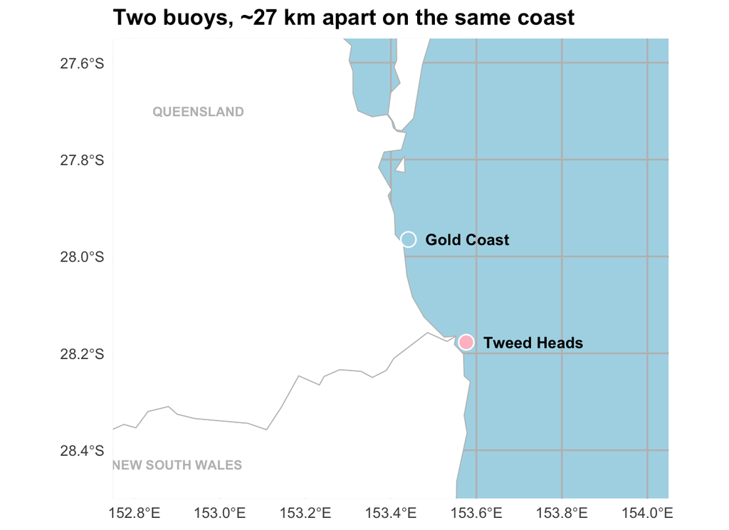

Figure 4: The two wave buoys: Gold Coast (QLD) and Tweed Heads (NSW), about 27 km apart on the same stretch of coast. State outlines from the ozmaps package.

```r
ggplot(states) +
  geom_sf(fill = "white", colour = "grey", linewidth = 0.3) +
  annotate("text", x = 152.95, y = -27.7,  label = "QUEENSLAND",
           colour = "grey", size = 3, fontface = "bold") +
  annotate("text", x = 152.9,  y = -28.43, label = "NEW SOUTH WALES",
           colour = "grey", size = 3, fontface = "bold") +
  geom_point(data = buoys, aes(lon, lat, fill = site),
             shape = 21, size = 4.2, stroke = 0.7, colour = "white") +
  geom_text(data = buoys, aes(lon, lat, label = site),
            hjust = 0, nudge_x = 0.04, size = 3.6, fontface = "bold") +
  scale_fill_manual(values = site_cols, guide = "none") +
  coord_sf(xlim = c(152.75, 154.05), ylim = c(-28.5, -27.55), expand = FALSE) +
  labs(x = NULL, y = NULL,
       title = "Two buoys, ~27 km apart on the same coast") +
  theme(panel.background = element_rect(fill = "lightblue", colour = NA),
        panel.grid = element_line(colour = "grey"))
```

At the **16,715** half-hours when both were recording, their wave heights agree to a correlation of **0.96** and their sea temperatures to **0.97**. The seasonal cycle and the storm spikes are not one float’s quirks — they are *the ocean*. Tweed runs a touch bigger (mean Hs **1.29** vs **1.15** m; biggest single wave **10.05** vs **7.47** m), consistent with its more exposed position.

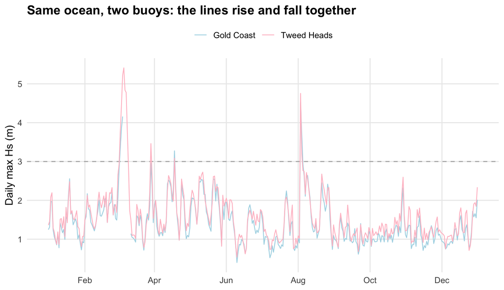

Figure 5: Daily maximum Hs at both buoys. The two lines move together all year and spike on the same days — but Gold Coast goes blank for much of March (its outage), exactly when a major swell hit. Tweed Heads, near-complete, covers the gap.

```r
waves %>%
  group_by(site, date) %>%
  summarise(max_hs = max(hs, na.rm = TRUE), .groups = "drop") %>%
  mutate(max_hs = ifelse(is.finite(max_hs), max_hs, NA_real_)) %>%
  ggplot(aes(date, max_hs, colour = site)) +
  geom_hline(yintercept = 3, linetype = "dashed", colour = "grey70") +
  geom_line(linewidth = 0.45) +
  scale_colour_manual(values = site_cols, name = NULL) +
  scale_x_date(date_breaks = "2 months", date_labels = "%b") +
  labs(x = NULL, y = "Daily max Hs (m)",
       title = "Same ocean, two buoys: the lines rise and fall together") +
  theme(legend.position = "top")
```

The payoff is **March**. Gold Coast lost **25.1%** of the month to its outage — right across a major event. Tweed Heads, **0.4%** missing, covered the gap and showed March peaking at **5.41 m** — *rougher* than Gold Coast’s broken record let on. The second buoy didn’t just confirm the story; it **rescued the part the first one dropped.** That, more than any single statistic, is the argument for reaching past one dataset.

#### A trap worth pointing out

It’s tempting to relate wave height to sea temperature directly, and if you do, you get a mild *positive* monthly correlation (**0.43**) — bigger waves in warmer months? That’s a **seasonal mirage**. It only appears because autumn happens to be *both* still-warm *and* the stormiest part of 2025; there’s no physical link. The two record-breaking events make the point better than any coefficient: one struck at 26.4°C and the other at 19.9°C. Sea temperature and wave height are driven by **different machines** — the sun’s slow heating versus the wind’s fast storms — and reading causation into their overlap is exactly the kind of mistake a year of honest data helps you avoid.

#### What the year says

Across 2025 the buoys told a four-part story: sea temperature and wave height **march to different drummers**; the big swells **arrive in a couple of bunches** rather than spread evenly, from opposite seasons; wave **period** quietly separates local chop from ocean swell; and a second buoy 27 km south **confirms all of it at ~96% agreement** — while quietly filling the gap the first buoy left in March. None of it is a forecast — it’s two buoys, one year — but it’s a satisfying amount of structure to pull out of a couple of yellow floats and a year of patience.

### References

- Department of Environment, Tourism, Science and Innovation (Queensland Government). *Coastal Data System – Waves (Gold Coast): Wave data – 2025* [data set]. CC BY 4.0. https://www.data.qld.gov.au/dataset/coastal-data-system-waves-gold-coast
- Department of Environment, Tourism, Science and Innovation (Queensland Government). *Coastal Data System – Waves (Tweed Heads): Wave data – 2025* [data set]. CC BY 4.0. https://www.data.qld.gov.au/dataset/coastal-data-system-waves-tweed-heads
- Queensland Government. *Wave monitoring — field definitions & site locations.* https://www.qld.gov.au/waves
- Wickham, H. et al. (2019). *Welcome to the tidyverse.* JOSS 4(43), 1686. R packages `tidyverse`, `lubridate`, `scales`.
- Pebesma, E. (2018). *Simple Features for R (`sf`).* The R Journal 10(1), 439–446. Australian state boundaries via the `ozmaps` package.

**Behind the Scenes**

### Q5 — The un-glamorous parts

Three pieces of drudgery shaped this analysis, and none of them would ever make a blog post.

First, the timestamps. The raw file stores time as text, like `2025-03-01T00:00`. If you let `read_csv()` guess the column type, every *midnight* reading silently loses its clock time, later fails to re-parse, and 365 rows — exactly one per day — vanish into a mystery “NA month”. Nothing crashes; the monthly averages are just quietly wrong. The fix is one line (read the column as text and parse it myself), but finding it meant counting rows per month until the numbers added up to what a year *should* contain.

Second, missing values in this data are not blanks — they are the number **-99.9**. A computer will happily average -99.9, which is how I briefly produced negative “mean wave heights”. All six measurement columns had to be recoded to `NA` before any summary was trustworthy.

Third, alignment. Tweed Heads’ file doesn’t stop on 31 December — it has 17,568 rows, 48 more than Gold Coast’s 17,520 — so a fair comparison meant clipping both buoys to calendar-2025. None of this is clever; it is checking what the data *is* against what it *should be* (48 half-hours × 365 days). But every number in the blog stands on it.

### Q6 — Challenges

The challenge I didn’t see coming was **silent data loss**. I assumed a government CSV would be “clean”, and it is — but my own reading code could still lose data without a single error message. The midnight bug taught me to validate the *shape* of the data, not just its values: the pipeline now asserts, per site, that there are exactly 17,520 rows, every timestamp parses, none are duplicated, and the 30-minute grid is unbroken. If any of that breaks, it fails loudly instead of lying quietly.

The second challenge was realising the missing data was **not missing at random**. Gold Coast lost ~25% of March, and the gap sat exactly on top of the year’s biggest swell — the outage was almost certainly *caused by* the storm I most wanted to measure. Just dropping the NAs would have silently under-counted the most interesting event in the data. That is what pushed me to bring in the Tweed Heads buoy: a near-complete second record that covered the gap, and showed March was even rougher than Gold Coast’s broken record suggested. Turning a missing-data problem into a finding is the part of this project I’m most pleased with.

The quietest challenge was self-discipline: wave height and sea temperature are positively correlated month-to-month, and it would have been easy to report that as a finding. It is really just two seasonal curves overlapping — a confound, not a relationship.

### Q7 — Imperfections & future work

The honest list:

- **Scope.** Two buoys and one year describe one corner of the coast in 2025. That is not a climatology, and 2025 might be an unusual year — none of the patterns here should be generalised without more years of data.
- **Missing data.** I dropped `NA`s rather than imputing them. For monthly averages that is reasonable; for *counting* big-wave half-hours during the March outage it biases the count downwards, which is why March’s event counts are reported as lower bounds.
- **A crude swell definition.** I separated swell from wind-sea using peak period alone. A better version would use wave steepness, and the `Peak Direction` column — which sits in the data completely unused — to split swell trains by where they actually come from.

Next steps: pull several years and more sites along the coast to test whether 2025’s “autumn-and-winter heavyweights” pattern is typical, and join wind observations so the wind-sea/swell story is confirmed by the wind rather than inferred from wave period.

### Q8 — How I used AI

In this assignment, I used AI as a learning aid rather than a replacement for my own work. I drew on AI techniques to help clean the Gold Coast wave data — in particular, recoding the -99.9 sentinel values as NA and parsing the half-hourly timestamps — which taught me how to apply systematic data-processing logic to a real natural phenomenon, where missing readings are not random but often coincide with storms or buoy maintenance.

It also helped me write and structure my .R script files more accurately. By asking the AI to explain errors and suggest cleaner approaches, I learned to organise my code into readable, reproducible steps and to debug more independently over time.

Furthermore, I gained a deeper understanding of mapping techniques using the ozmaps and sf packages. The AI clarified how spatial data is stored as simple-features geometries and how to layer a monitoring-site point onto an Australian coastline map, which I then adapted and verified myself.

Throughout, I treated AI suggestions as a starting point: I tested every piece of code against my actual data, confirmed the output made sense, and made sure I understood the reasoning before including it.

### Q9 — Four iterations

The iteration record is this [repo’s](https://github.com/Hanwen-L/ETC5512-Assignment4) four commits, and they show the work was not a straight line:

1. **`add template and data`** — the unit template plus both raw CSVs and the download script, committed *before* any analysis so every later step runs against a fixed, untouched input. The exploratory code at this point contains both early mistakes: the midnight-parsing bug and `-99.9` still being averaged as if it were data.
2. **`Task 1`** — the data work: the cleaning pipeline (timestamp fix, sentinel recoding, clipping Tweed Heads to 2025), the per-site assertions, and the documentation (`metadata.md`, `data_dictionary.csv`). The fixes in this commit changed every number downstream.
3. **`Task 2`** — the blog: the four analyses (two seasonal rhythms, big-wave clustering, swell vs wind-sea, the two-buoy cross-check), with every statistic computed inline from the data instead of typed by hand, so the prose cannot drift from the data.
4. **`Task 3`** — this commit: the reflections in this tab, the rewritten README, and final polish.

Compared with my early-feedback checklist, two things changed: the separate “does SST show a seasonal cycle” sub-question was folded into the *two rhythms* comparison, and the second buoy was added. The Tweed Heads cross-check wasn’t in the original plan at all — it grew out of the March missing-data problem, and ended up being the strongest part of the post.

### AI Use Statement

In this assignment, I only used AI to assist with the correct use of R code and enhance analytical thinking and academic writing in English.

More specifically, I used AI to :

- Suggestions about data cleaning.
- How to use .r files in Assignment 4.
- What are the limitations of the dataset?
- How to create a buoy map
- What kind of images can improve the quality of a post?

I created all code, visuals, written text and interpretations independently.

Here is the [link](https://gemini.google.com/share/7f444e328bcf) to all prompts used.